### Public Health and Economoic Consequences of Severe Weather in the U.S.

### Synopsis

This analysis aims to answer two key questions about severe weather and related atmospheric and meteorlogical activity in the U.S.:

- Which types of events are most harmful with respect to population health?
- Which types of events have the greatest economic consequences?

The focus will be on determining the top 10 events separately for both health impact and economic consequences separetly.

The decision was made to take property and crop damage estimates as-is and not adjust amounts for inflation. Further analysis that adjusts for inflation and/or analyzes data by year may yield different results. Further decisions regarding standardization of Event Types will be discussed under the Results section.

### Data Repository

Data was obtained from the U.S. National Oceanic and Atmospheric Administration’s (NOAA) storm database between 1950 and November 2011. Data may be downloaded here: https://d396qusza40orc.cloudfront.net/repdata%2Fdata%2FStormData.csv.bz2.

### Data Definitions and Documentation

- National Weather Service Storm Data Documentation may be found here: https://d396qusza40orc.cloudfront.net/repdata%2Fpeer2_doc%2Fpd01016005curr.pdf
- National Climatic Data Center Storm Events FAQ may be found here: https://d396qusza40orc.cloudfront.net/repdata%2Fpeer2_doc%2FNCDC%20Storm%20Events-FAQ%20Page.pdf

With this analysis limited to health and economic damages across the U.S. as a whole and without regard to the timing or year of the event, we need only consider the columns below from the dataset: - EVTYPE: type of event (i.e. Hail, Tornado, Flash Flood) - FATALITIES: deaths related to the event - INJURIES: injuries related to the event - PROPDMG: amount of property damage - PROPDMGEXP: multiplier for property damage. (0-1: 1; H: 100; K: 1,000; M: 1,000,000; B: 1,000,000,000) - CROPDMG: Base amount of crop damage. - CROPDMGEXP: Base multiplier for crop damage. (0-1: 1; H: 100; K: 1,000; M: 1,000,000; B: 1,000,000,000)

### Data Processing

```r
# load required libraries
library(knitr)
library(ggplot2)

#change this line to your workind directory if reproducing this research
setwd("/Users/schre/DataScience/wd/repro_research/Project2")

#read in data
if(!file.exists("./data")){dir.create("./data")}
if (!file.exists('data/repdata%2Fdata%2FStormData.csv.bz2')) {
      fileurl <- "https://d396qusza40orc.cloudfront.net/repdata%2Fdata%2FStormData.csv.bz2"
      download.file(fileurl, 'data/repdata%2Fdata%2FStormData.csv.bz2')
}
storm.data <- read.csv("data/repdata%2Fdata%2FStormData.csv.bz2", strip.white = TRUE,
                 stringsAsFactors = FALSE)
```

First, we will eliminate any columns not required:

```r
#limit data to only those columns we need
storm.data <- subset(storm.data, select = c(EVTYPE,FATALITIES,INJURIES,PROPDMG,
                  PROPDMGEXP,CROPDMG,CROPDMGEXP))
```

Second, to make better sense of the property and crop damage numbers, we will take the cost x the multiplier (H, K, M, B) and create a new column called “propdmg” and “cropdmg”:

```r
storm.data$propdmg <- 0
storm.data[storm.data$PROPDMGEXP == "H", ]$propdmg <-
  storm.data[storm.data$PROPDMGEXP == "H", ]$PROPDMG * 10^2

storm.data[storm.data$PROPDMGEXP == "K", ]$propdmg <-
  storm.data[storm.data$PROPDMGEXP == "K", ]$PROPDMG * 10^3

storm.data[storm.data$PROPDMGEXP == "M", ]$propdmg <-
  storm.data[storm.data$PROPDMGEXP == "M", ]$PROPDMG * 10^6

storm.data[storm.data$PROPDMGEXP == "B", ]$propdmg <-
  storm.data[storm.data$PROPDMGEXP == "B", ]$PROPDMG * 10^9

storm.data$cropdmg <- 0
storm.data[storm.data$CROPDMGEXP == "H", ]$cropdmg <-
  storm.data[storm.data$CROPDMGEXP == "H", ]$CROPDMG * 10^2

storm.data[storm.data$CROPDMGEXP == "K", ]$cropdmg <-
  storm.data[storm.data$CROPDMGEXP == "K", ]$CROPDMG * 10^3

storm.data[storm.data$CROPDMGEXP == "M", ]$cropdmg <-
  storm.data[storm.data$CROPDMGEXP == "M", ]$CROPDMG * 10^6

storm.data[storm.data$CROPDMGEXP == "B", ]$cropdmg <-
  storm.data[storm.data$CROPDMGEXP == "B", ]$CROPDMG * 10^9
```

### Results

Between 1950 to November 2011 the U.S. has seen a total of 15,145 fatalaties and 140,528 injuries:

```r
sum(storm.data$FATALITIES)
```

```
## [1] 15145
```

```r
sum(storm.data$INJURIES)
```

```
## [1] 140528
```

Furthermore, property and crop damage is an estimated $427 and $49 billion respectively:

```r
paste("$",format(sum(storm.data$propdmg), big.mark=","),sep="")
```

```
## [1] "$427,279,744,600"
```

```r
paste("$",format(sum(storm.data$cropdmg), big.mark=","),sep="")
```

```
## [1] "$49,093,755,910"
```

In order to break down these numbers we first must recognize that there are event types are not standardized. The dataset constains 985 distinct event types. Many of these are similar, vague terms or even combinations of some event types. For example, “Thunderstorm”, “Wind” and “Flood” are common events, but we can find both “Flash Flooding/Thunderstorm”, “Thunderstorm Wind”, etc. In fact, there are 101 event types containing the word ‘flood’.

Our strategy will be to view the top 20 events and using regular expressions we’ll combine similar event types. An initial plot of the top 20 events then looks like so:

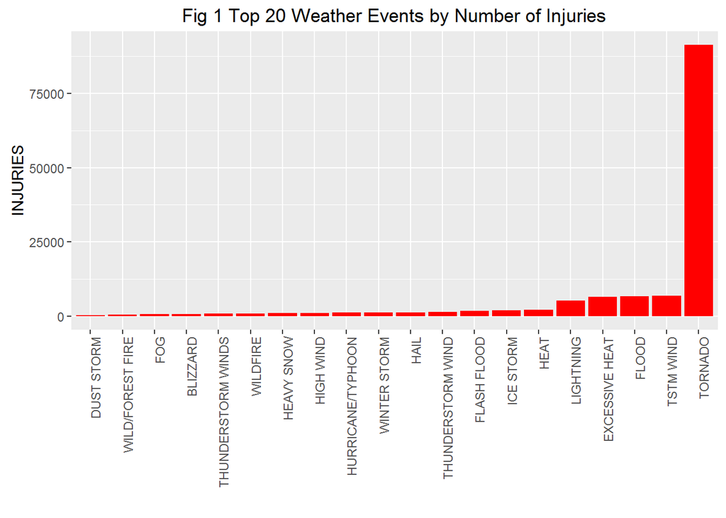

```r
#Find the top 20 event types in order to derive the EVTYPE names we
#will later use in our regular expressions

storm.data.injuries <- aggregate(INJURIES ~ EVTYPE, data=storm.data, sum)
storm.data.injuries <-
      storm.data.injuries[order(-storm.data.injuries$INJURIES), ][1:20, ]
storm.data.injuries <- transform(storm.data.injuries, EVTYPE = reorder(EVTYPE, INJURIES))

ggplot(storm.data.injuries, aes(x = EVTYPE, y = INJURIES)) +
  geom_bar(stat = "identity", fill = "red") +
  theme(axis.text.x = element_text(angle = 90, hjust = 1)) +
  xlab("") + ylab("INJURIES") +
  ggtitle("Fig 1 Top 20 Weather Events by Number of Injuries")
```

From this we see that we can combine the events: FLASH FLOOD and FLOOD; THUNDERSTORM WIND, THUNDERSTORM WINDS, and TSTM WIND; EXCESSIVE HEAT and HEAT; BLIZZARD, HEAVY SNOW, ICE STORM, and WINTER STORM.

```r
#Standardize event types
storm.data$EVTYPE[grep("THUN|TSTM", storm.data$EVTYPE, ignore.case = TRUE)] <- "THUNDERSTORM"
storm.data$EVTYPE[grep("FLOOD", storm.data$EVTYPE, ignore.case = TRUE)] <- "FLOOD"
storm.data$EVTYPE[grep("TORN", storm.data$EVTYPE, ignore.case = TRUE)] <- "TORNADO"
storm.data$EVTYPE[grep("BLIZZARD|SNOW|ICE|FREEZE", storm.data$EVTYPE, ignore.case =
                             TRUE)] <- "WINTER STORM"
storm.data$EVTYPE[grep("HURRICANE", storm.data$EVTYPE, ignore.case = TRUE)] <- "HURRICANE"
storm.data$EVTYPE[grep("HEAT", storm.data$EVTYPE, ignore.case = TRUE)] <- "HEAT"
```

Next we will re-plot using the top 10 events for impacts on health. In this analysis injuries and fatalities will simply be added together, no distinction will be made to their relative effects, as the relative serious of injuries alone cannot be determined.

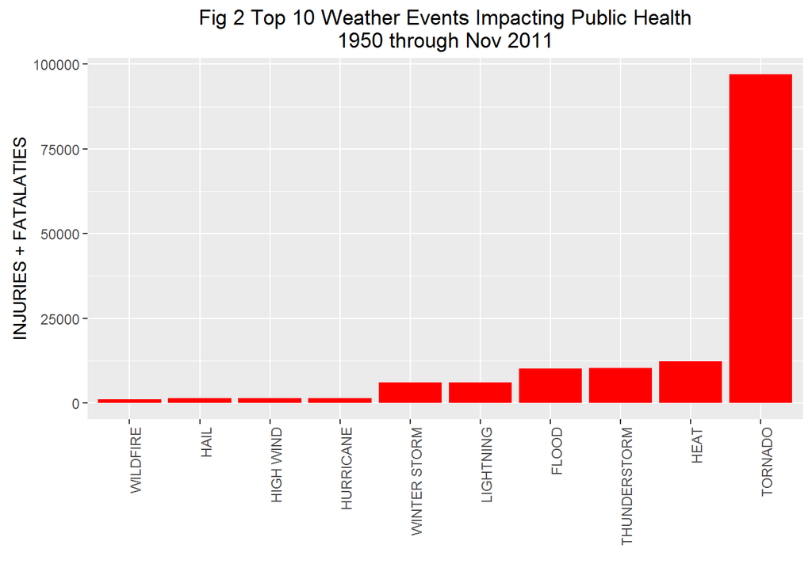

```r
storm.data.health <- setNames(aggregate(INJURIES+FATALITIES ~ EVTYPE,
      data=storm.data, sum), c("EVTYPE", "VALUE"))

storm.data.health <-
      storm.data.health[order(-storm.data.health$VALUE), ][1:10, ]
storm.data.health <- transform(storm.data.health, EVTYPE = reorder(EVTYPE, VALUE))

ggplot(storm.data.health, aes(x = EVTYPE, y = VALUE)) +
    geom_bar(stat = "identity", fill = "red") +
    theme(axis.text.x = element_text(angle = 90, hjust = 1)) +
    xlab("") + ylab("INJURIES + FATALATIES") +
    ggtitle("Fig 2 Top 10 Weather Events Impacting Public Health\n1950 through Nov 2011")
```

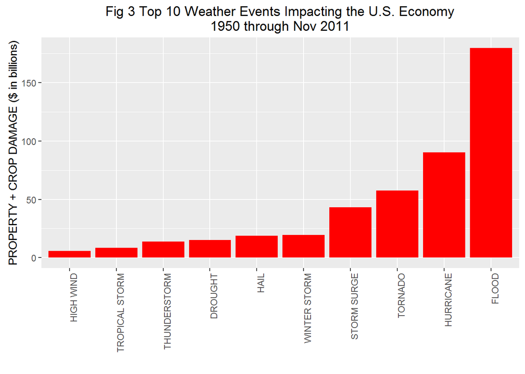

```r
storm.data.econ <- setNames(aggregate(propdmg+cropdmg ~ EVTYPE,
      data=storm.data, sum), c("EVTYPE", "VALUE"))

storm.data.econ <-
      storm.data.econ[order(-storm.data.econ$VALUE), ][1:10, ]
storm.data.econ <- transform(storm.data.econ, EVTYPE = reorder(EVTYPE, VALUE))

ggplot(storm.data.econ, aes(x = EVTYPE, y = VALUE/10^9)) +
    geom_bar(stat = "identity", fill = "red") +
    theme(axis.text.x = element_text(angle = 90, hjust = 1)) +
    xlab("") + ylab("PROPERTY + CROP DAMAGE ($ in billions)") +
    ggtitle("Fig 3 Top 10 Weather Events Impacting the U.S. Economy\n1950 through Nov 2011")
```